# Analyze Shaw Bros

```r
library(ggthemes)
library(tidyjson)
library(tidyverse)
library(forcats)
```

## Read in Data

Read the JSON into a string.

```r
filename = '../out/shaw.json'
shaw_json <- paste(readLines(filename), collapse="")
```

```
incomplete final line found on '../out/shaw.json'
```

Use `tidyjson` to convert a table format we can work with.

```r
films <- shaw_json %>% as.tbl_json %>% gather_array %>%
  spread_values(
    title = jstring("title"),
    director = jstring('director'),
    year = jstring('year'),
    avg_rating = jstring('avg_rating'),
    watches = jstring("watches"),
    likes = jstring("likes")
  )
```

```r
cast <- shaw_json  %>% as.tbl_json  %>% gather_array %>%
  spread_values(
    title = jstring("title"),
    director = jstring('director'),
    year = jstring('year'),
    avg_rating = jstring('avg_rating'),
    watches = jstring("watches"),
    likes = jstring("likes")
  ) %>% enter_object("cast") %>% gather_array() %>%
  spread_values(
    name = jstring("name")
  )
```

Right now characters are a separte array

```r
characters <- shaw_json  %>% as.tbl_json  %>% gather_array %>%
  spread_values(
    title = jstring("title"),
    director = jstring('director'),
    year = jstring('year'),
    avg_rating = jstring('avg_rating'),
    watches = jstring("watches"),
    likes = jstring("likes")
  ) %>% enter_object("characters") %>% gather_array() %>%
  spread_values(
    name = jstring("name")
  )
```

How many films?

```r
nrow(films)
```

```
[1] 260
```

260! That’s a lot of kung-fu. Let’s take a look at these films from a few different angles. We can start with Time

### Shaw Brothers, Through The Ages

To start, let’s look at when the films were made.

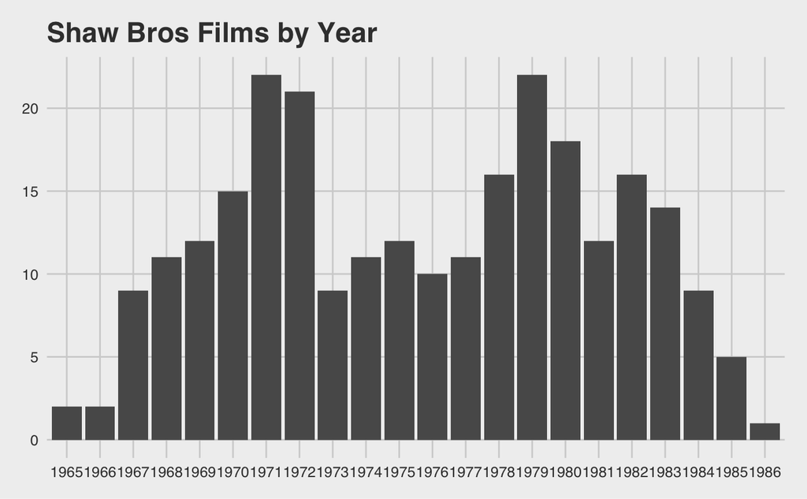

```r
films %>% ggplot(aes(x = year)) +
  geom_bar() +
  labs(title = 'Shaw Bros Films by Year') +
  theme_fivethirtyeight()
```

The first Kung-fu Shaw Brothers film in this data set is [Temple of the Red Lotus](https://letterboxd.com/film/temple-of-the-red-lotus/) from 1965. From the reviews, it sounds like it was a bit rough around the edges - but thats about what you would expect from this burgeoning genre.

The studio hits its stride in the early 70’s, with a lull in the mid 70’s and another spike in the late 70’s, early 80’s. Keep in mind that even during the lull, the studio is still putting out 10 or more Kung-fu movies most years.

### Shaw Brothers Directorial Favorites

We should have director for each movie, let’s look to see if there are any popular standouts.

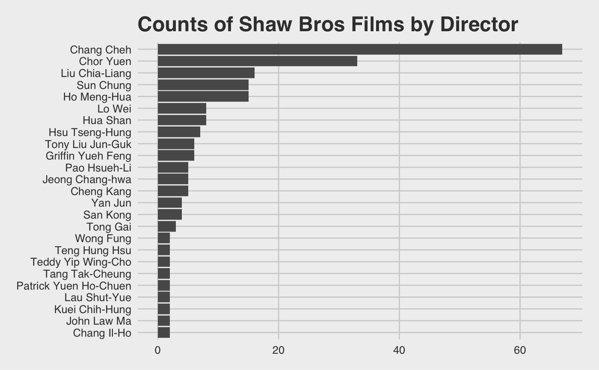

```r
by_director <- films %>% group_by(director) %>% summarise(n = n()) %>% arrange(-n)
  by_director %>% filter(n > 1) %>%
  ggplot(aes(x = fct_reorder(director, n), y = n)) +
  geom_bar(stat = "identity") +
  coord_flip() +
  labs(title = 'Counts of Shaw Bros Films by Director') +
  theme_fivethirtyeight()
```

I’d say! [Chang Cheh](https://en.wikipedia.org/wiki/Chang_Cheh) directed 67 or roughly 26% of all Shaw Brothers Kung-fu!

According to his Wikipedia page, he was known as the “The Godfather of Hong Kong cinema”, and rightly so - at least in terms of quantity.

Let’s pull out the top 5 directors, in terms of movie count, and see when they were most active.

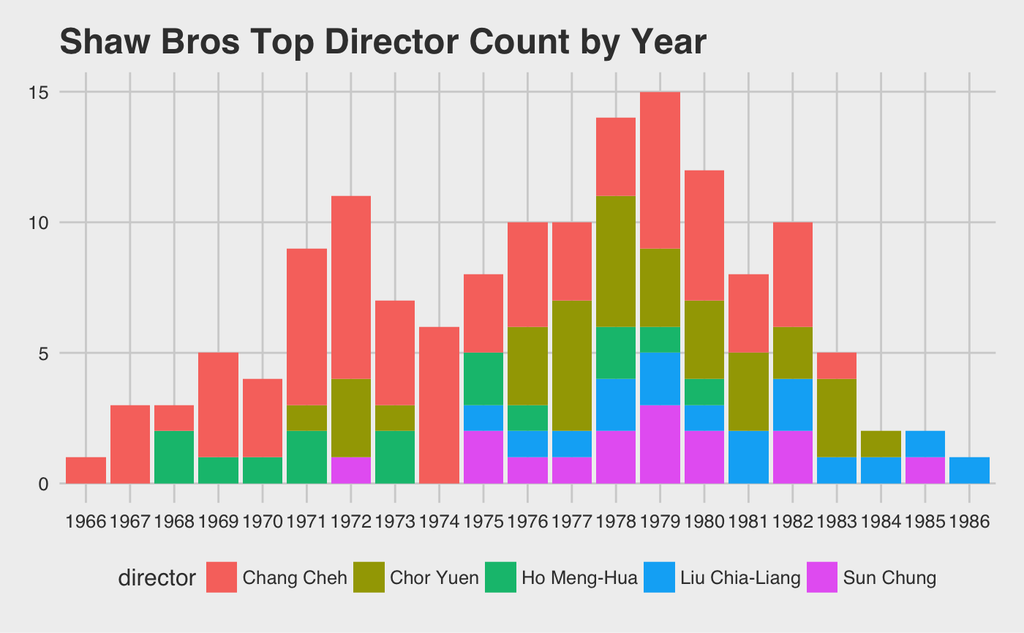

```r
# pull out just the top 5 directors
top_directors <- by_director %>% head(n = 5)
# filter films to those directed by these titans of kung-fu
films_top_director <- films %>% filter(director %in% top_directors$director)
films_top_director %>%
  ggplot(aes(x = year)) +
  geom_bar(aes(fill = director)) +
  labs(title = 'Shaw Bros Top Director Count by Year') +
  theme_fivethirtyeight()
```

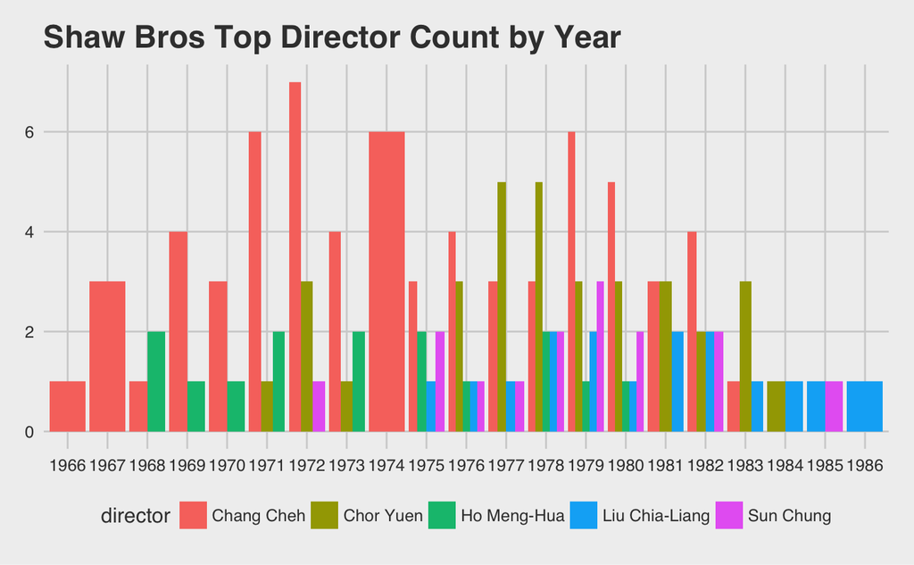

```r
films_top_director %>%
  ggplot(aes(x = year)) +
  geom_bar(aes(fill = director), position = "dodge") +
  labs(title = 'Shaw Bros Top Director Count by Year') +
  theme_fivethirtyeight()
```

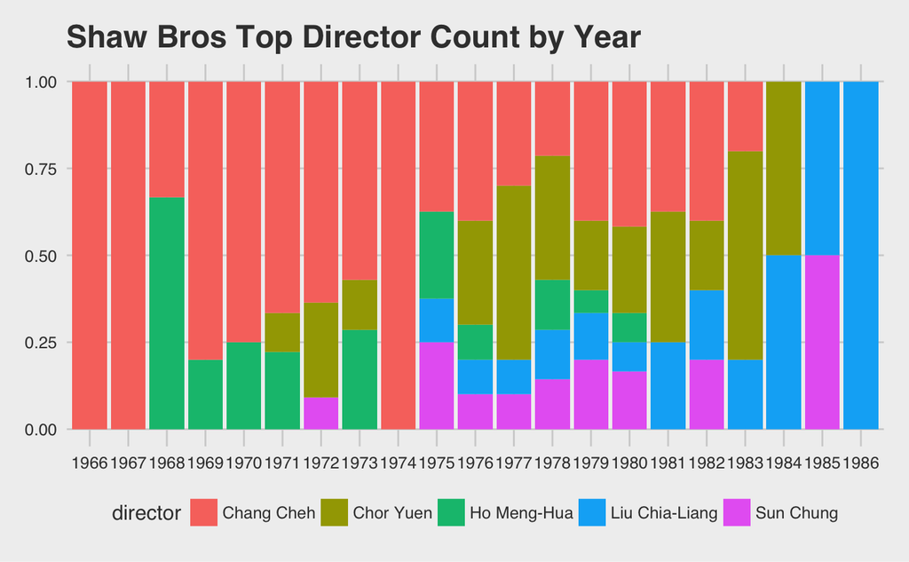

```r
# Try Fill Position
films_top_director %>%
  ggplot(aes(x = year)) +
  geom_bar(aes(fill = director), position = "fill") +
  labs(title = 'Shaw Bros Top Director Count by Year') +
  theme_fivethirtyeight()
```

That was with filtering to *just* the top directors. What happens when we put all of them in?

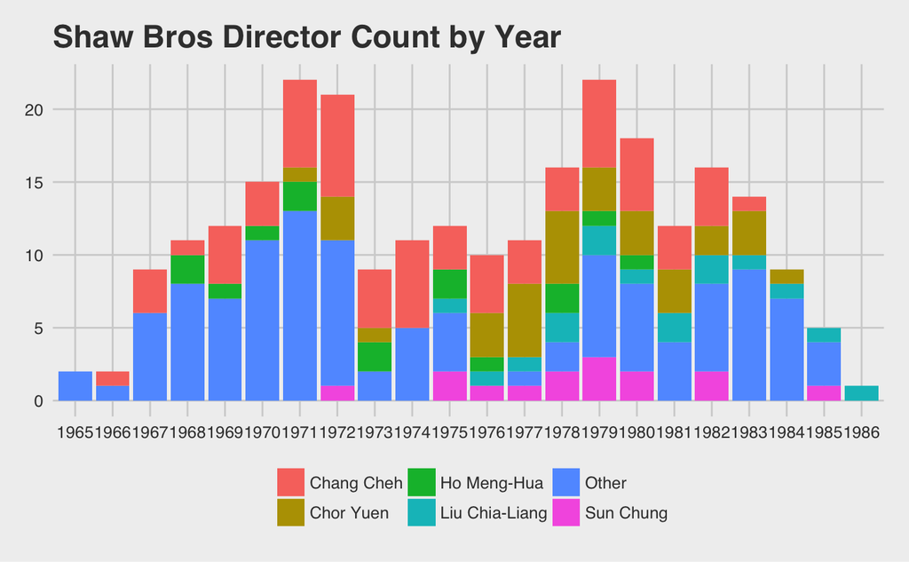

```r
films_top_director_all <- films %>% mutate(director_label = ifelse(director %in% top_directors$director, director, 'Other'))
films_top_director_all %>%
  ggplot(aes(x = year)) +
  geom_bar(aes(fill = director_label)) +
  labs(title = 'Shaw Bros Director Count by Year', fill = '') +
  theme_fivethirtyeight()
```

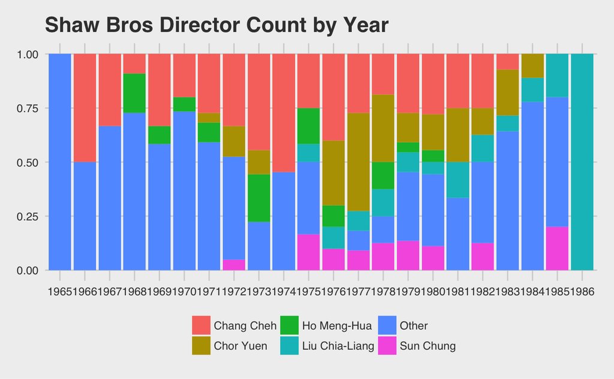

```r
films_top_director_all %>%
  ggplot(aes(x = year)) +
  geom_bar(aes(fill = director_label), position = 'fill') +
  labs(title = 'Shaw Bros Director Count by Year', fill = '') +
  theme_fivethirtyeight()
```

## Actor Troupes and Groups

Even with my novice-level consuption of Shaw Brothers films, one thing I noticed early on was a lot of familiar faces that showed up in many of the movies. My assumption is just like directors, there are a number of actors that are heavily reused in these films. Let’s see if I am right!

First, just like directors, we can look at counts by actor.

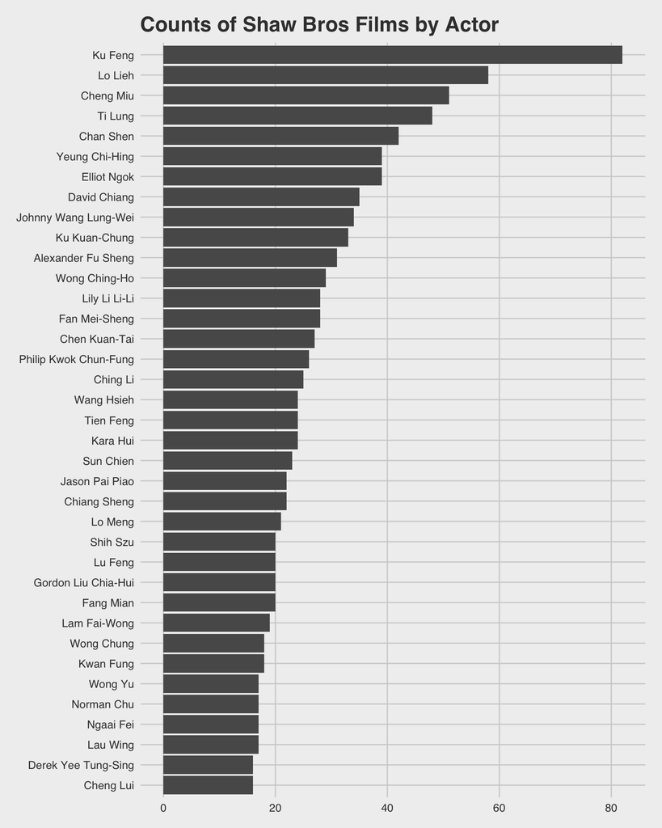

```r
by_actor <- cast %>% group_by(name) %>% summarise(n = n()) %>% arrange(-n)
by_actor %>% filter(n > 15) %>%
  ggplot(aes(x = fct_reorder(name, n), y = n)) +
  geom_bar(stat = "identity") +
  coord_flip() +
  labs(title = 'Counts of Shaw Bros Films by Actor') +
  theme_fivethirtyeight()
```

Wow! [Ku Feng](https://en.wikipedia.org/wiki/Ku_Feng) apparently appeared in 82 Kung-Fu movies. That’s a lot of Kung-Fu!

His Wikipedia page isn’t as impressed with this feat as I am, providing little information on this Martial Arts Maniac. Apparently his real name is Chan Sze-man, and his first film was in 1959, and apparently he is still acting. The [HKMDB](http://hkmdb.com/db/people/view.mhtml?id=3579&display_set=eng), or Hong Kong Movie Database, provides just a bit more info:

> In 1965, Ku formally signed an acting contract with Shaw Brothers where he made around 100 films for them and became most notably known as one of their top character actors. He has worked with just about every top Hong Kong director in a variety of films.

Ok then, well props to you Ku.

Did most of the top actors’ carreers span multiple decades, or did actors come and go quickly? Let’s graph the top actor’s movie count by year.

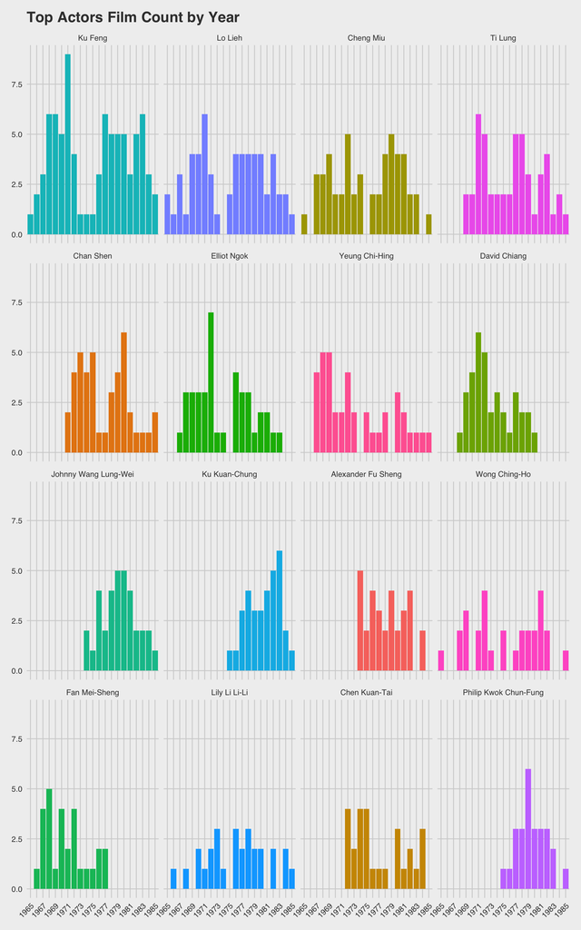

```r
top_actor <- by_actor %>% head(n = 16)
films_top_actor <- cast %>% filter(name %in% top_actor$name)
films_top_actor %>%
  ggplot(aes(x = year, fill = name)) +
  geom_bar() +
  labs(title = 'Top Actors Film Count by Year') +
  facet_wrap( ~ fct_relevel(name, top_actor$name)) +
  # only label half of the years to make things a bit look cleaner
  scale_x_discrete(labels = function(x) { return(ifelse(as.numeric(x) %% 2, x, '')) }) +
  theme_fivethirtyeight() +
  # angle label text
  theme(axis.text.x = element_text(angle = 45, hjust = 1), legend.position="none")
```

## Title Showdown

```r
library(tidytext)
```

```r
titles <- films %>% mutate(raw_title = title) %>% unnest_tokens(word, title)
```

```r
titles_filter <- titles %>% anti_join(stop_words, by = "word")
```

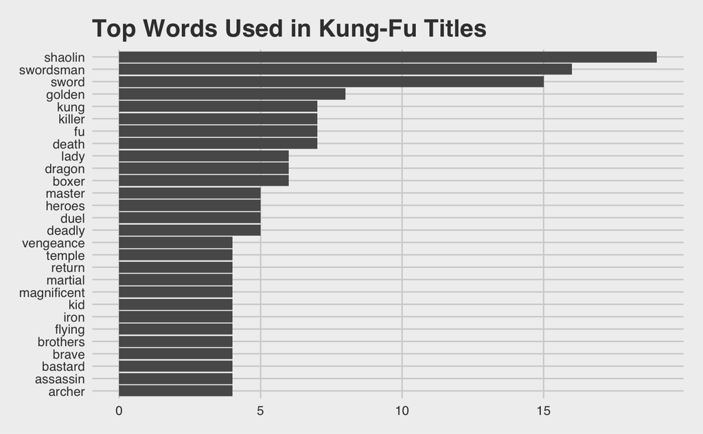

```r
by_word <- titles_filter %>% count(word, sort = TRUE)
  by_word %>%
  filter(n > 3) %>%
  ggplot(aes(x = fct_reorder(word, n), y = n)) +
  geom_bar(stat = 'identity') +
  coord_flip() +
  labs(title = 'Top Words Used in Kung-Fu Titles') +
  theme_fivethirtyeight()
```

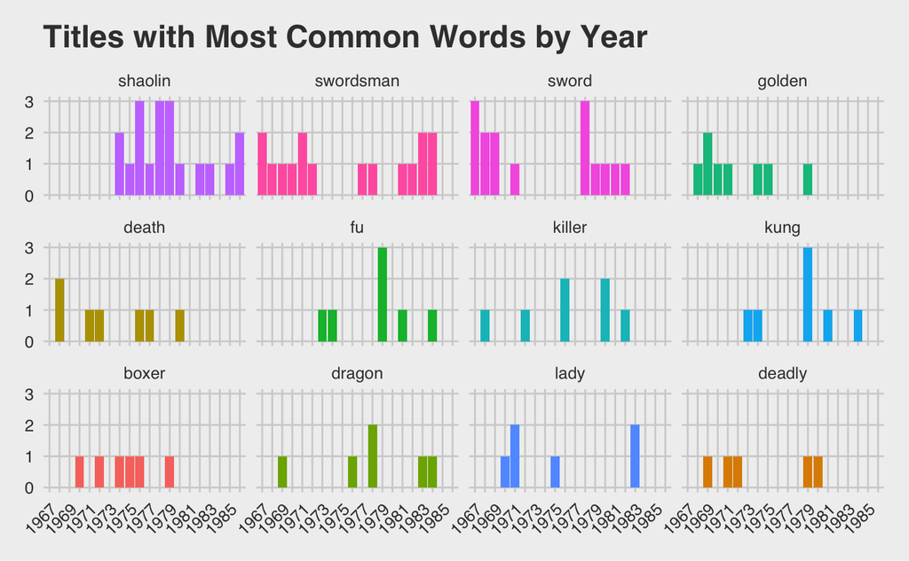

```r
top_word <- by_word %>% head(n = 12)
films_top_word <- titles %>% filter(word %in% top_word$word)
films_top_word %>%
  ggplot(aes(x = year, fill = word)) +
  geom_bar() +
  labs(title = 'Titles with Most Common Words by Year') +
  facet_wrap( ~ fct_relevel(word, top_word$word)) +
  scale_x_discrete(labels = function(x) { return(ifelse(as.numeric(x) %% 2, x, '')) }) +
  theme_fivethirtyeight() +
  theme(axis.text.x = element_text(angle = 45, hjust = 1), legend.position="none")
```

Swordsman or Shaolin?

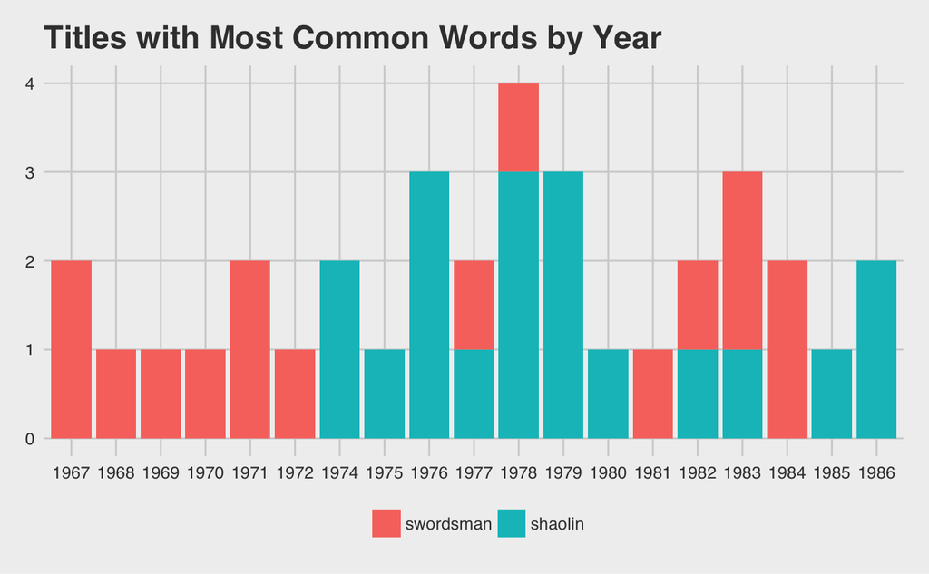

```r
top2_word <- by_word %>% head(n = 2)
films_top2_word <- titles %>% filter(word %in% top2_word$word)
films_top2_word %>%
  ggplot(aes(x = year, fill = fct_inorder(word))) +
  geom_bar() +
  labs(title = 'Titles with Most Common Words by Year', fill = '') +
  #scale_x_discrete(labels = function(x) { return(ifelse(as.numeric(x) %% 2, x, '')) }) +
  theme_fivethirtyeight()
```

```r
  #theme(axis.text.x = element_text(angle = 45, hjust = 1))
```

Swordsman Titles

```r
titles %>% filter(word == 'swordsman') %>% arrange(year) %>% select(raw_title, year)
```

|  | raw_title | year |
| --- | --- | --- |
| 1 | The Silent Swordsman | 1967 |
| 2 | The One-Armed Swordsman | 1967 |
| 3 | The Magnificent Swordsman | 1968 |
| 4 | Return Of The One Armed Swordsman | 1969 |
| 5 | The Wandering Swordsman | 1970 |
| 6 | Swordsman At Large | 1971 |
| 7 | The New One-Armed Swordsman | 1971 |
| 8 | The Imperial Swordsman | 1972 |
| 9 | The Sentimental Swordsman | 1977 |
| 10 | Swordsman and Enchantress | 1978 |

[output cut: 6 more lines]

Shaolin Titles

```r
titles %>% filter(word == 'shaolin') %>% arrange(year) %>% select(raw_title, year)
```

|  | raw_title | year |
| --- | --- | --- |
| 1 | Shaolin Martial Arts | 1974 |
| 2 | Five Shaolin Masters | 1974 |
| 3 | Disciples of Shaolin | 1975 |
| 4 | The Shaolin Avengers | 1976 |
| 5 | Shaolin Temple | 1976 |
| 6 | New Shaolin Boxers | 1976 |
| 7 | Executioners from Shaolin | 1977 |
| 8 | Shaolin Handlock | 1978 |
| 9 | Shaolin Mantis | 1978 |
| 10 | Invincible Shaolin | 1978 |

[output cut: 9 more lines]

From [History in the Shaw Brothers](http://thevulgarcinema.com/2015/12/history-in-the-shaw-brothers/)

> These films, focused on the Shaolin Temple as a center for anti-Qing resistance, provide a dizzying metaphorical potential, with the Qing variously standing in for Western imperialists, the Japanese, the Nationalist Kuomingtang, the Communists, or even simply the Manchurians themselves, while the Buddhism of the monks allows for examining of the contradictions at the heart of traditional Chinese belief systems, between the imperatives of social justice and withdrawal from worldly concerns.